# Istanbul 2009-2019 Weather Report Analysis

How weather patterns affect Istanbul farmers?

520444627, 520463743, 520490369, 510425995, 520466179

University of Sydney | MATH1005 | Lab Class Wednesday 3pm

# 1 Executive Summary

This report centres around the 2009-2019 Istanbul Weather data set that is comprised of readings of the weather reported in the city. The data set is readily available to the public online considering 3896 days considering 11 different weather readings. These readings are given according to the date and include the sun and moon rise and set, maximum and minimum temperature, average humidity, average rainfall, average wind and the rainfall. In this report, the motivations behind the data collection and relevance, the validity of the data set in today’s climate and possible limitations with the data set have been considered when creating the questions researched. In research question one: We found that as temperature rises, humidity tends to fall. And finally in research question two: We found that as humidity rises, rainfall tends to increase.

# 2 Full Report

## 2.1 Initial Data Analysis (IDA)

The data set was found on Kaggle. In the data each column represents a different variable of the weather report while each row represents the different conditions relevant to that day. After analysis, along with an 8.61 usability rating, the source World Weather Online found the data predominantly matched these direct weather reports. One limitation includes the data being three years old with updated data available. Due to the high variability of weather with climate change’s effect according to UCAR Centre for Education it presents this issue. Upon investigating the data on the website, it found there are limitations created via rounding errors. While still posing an issue these discrepancies are rare, for example on 31/08/2019, ‘World Weather’ said the minimum temperature was 21°C compared to the data set with minimum 22°C. Although, like the data set displays, the website likewise reported there was 0.5mm of rain and average wind of 22kn. Source ‘Time and Date Weather’ enabled this data to be rechecked. This website revealed the minimum temperature was 22°C with 0.5mm of rain and 22kn of wind. A third source, TckTckTck again supported the reliability of our data identifying there was 0.5mm of rain and 22kn was the average wind speed. A stakeholder of this data is Turkish farmers. Food markets are popular in Istanbul so it’s pivotal for farmers to analyse past weather patterns to assess when certain crops should be planted and then harvested to maximise produce and its quality. Hence as stakeholders, these farmers would be interested in how the humidity varies with temperature over the year and then how this humidity changes with rainfall (affecting crops with variance). The government is another stakeholder due to curiosity about future weather when budgeting for natural disasters like droughts which are common in Turkey (NASA Earth Observatory).

Variable analysis was conducted uncovering that the variables relating to time were incorrectly perceived by R as character variables. However, due to scope of project, the quantitative discrete numeric variables MinTemp, MaxTemp, AvgWind, AvgHumidity, and AvgPressure were investigated. We also investigated Rainfall, a continuous numerical variable and Condition which is a categorical nominal variable.

```r
Assignmentdata <- read.csv("data/Istanbul Weather Data (2).csv")
```

```r
str(Assignmentdata)
```

```
## 'data.frame':    3896 obs. of  16 variables:
##  $ DateTime   : chr  "02.09.2019" "01.09.2019" "31.08.2019" "30.08.2019" ...
##  $ Condition  : chr  "Partly cloudy" "Partly cloudy" "Patchy rain possible" "Partly cloudy" ...
##  $ Rain       : num  0 0 0.5 0 0 0 0 0 0 0 ...
##  $ MaxTemp    : int  27 27 26 27 27 28 30 30 30 30 ...
##  $ MinTemp    : int  22 22 22 22 23 24 24 24 24 24 ...
##  $ SunRise    : chr  "6:32:00" "6:31:00" "6:30:00" "6:29:00" ...
##  $ SunSet     : chr  "19:37:00" "19:38:00" "19:40:00" "19:42:00" ...
##  $ MoonRise   : chr  "9:52:00" "8:37:00" "7:21:00" "6:04:00" ...
##  $ MoonSet    : chr  "21:45:00" "21:13:00" "20:40:00" "20:05:00" ...
##  $ AvgWind    : int  23 21 22 20 24 27 27 25 20 19 ...
##  $ AvgHumidity: int  66 66 63 64 61 58 61 66 69 71 ...
##  $ AvgPressure: int  1012 1011 1015 1016 1015 1016 1016 1015 1015 1017 ...
##  $ X          : logi  NA NA NA NA NA NA ...
##  $ MaxTemp.1  : int  27 27 26 27 27 28 30 30 30 30 ...
##  $ MinTemp.1  : int  22 22 22 22 23 24 24 24 24 24 ...
##  $ AvgTemp    : num  24.5 24.5 24 24.5 25 26 27 27 27 27 ...
```

```r
summary(Assignmentdata)
```

```
##    DateTime          Condition              Rain            MaxTemp
##  Length:3896        Length:3896        Min.   : 0.0000   Min.   :-3.00
##  Class :character   Class :character   1st Qu.: 0.0000   1st Qu.:12.00
##  Mode  :character   Mode  :character   Median : 0.0100   Median :18.00
##                                        Mean   : 0.9468   Mean   :18.08
##                                        3rd Qu.: 0.7200   3rd Qu.:25.00
##                                        Max.   :42.0000   Max.   :37.00
##     MinTemp        SunRise             SunSet            MoonRise
##  Min.   :-5.00   Length:3896        Length:3896        Length:3896
##  1st Qu.: 8.00   Class :character   Class :character   Class :character
##  Median :14.00   Mode  :character   Mode  :character   Mode  :character
##  Mean   :13.77
##  3rd Qu.:20.00
##  Max.   :26.00
##    MoonSet             AvgWind       AvgHumidity     AvgPressure
##  Length:3896        Min.   : 2.00   Min.   :40.00   Min.   : 992
##  Class :character   1st Qu.:11.00   1st Qu.:65.00   1st Qu.:1011
##  Mode  :character   Median :16.00   Median :71.00   Median :1015
##                     Mean   :16.99   Mean   :71.41   Mean   :1015
##                     3rd Qu.:22.00   3rd Qu.:78.00   3rd Qu.:1019
##                     Max.   :56.00   Max.   :97.00   Max.   :1038
##     X             MaxTemp.1       MinTemp.1        AvgTemp
##  Mode:logical   Min.   :-3.00   Min.   :-5.00   Min.   :-3.50
##  NA's:3896      1st Qu.:12.00   1st Qu.: 8.00   1st Qu.:10.00
##                 Median :18.00   Median :14.00   Median :15.50
##                 Mean   :18.08   Mean   :13.77   Mean   :15.93
##                 3rd Qu.:25.00   3rd Qu.:20.00   3rd Qu.:22.50
##                 Max.   :37.00   Max.   :26.00   Max.   :30.00
```

The data has dimensions 3896 entries with 16 columns.

```r
dim(Assignmentdata)
```

```
## [1] 3896   16
```

By running the code below, it was found that the most prevalent weather condition was 'sunny' which occurred on 2242 days, followed by 'partly cloudy' (781 days).

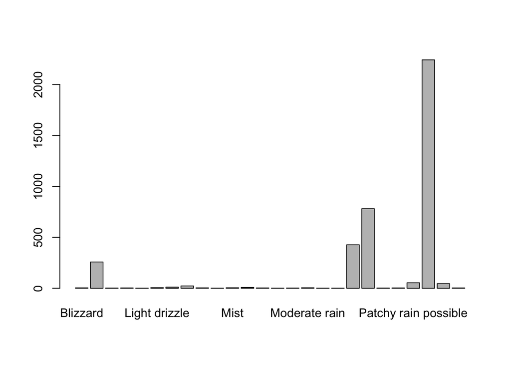

```r
barplot(table(Assignmentdata$Condition))
```

```r
table(Assignmentdata$Condition)
```

```
##
##                            Blizzard                              Cloudy
##                                   4                                 258
##                                 Fog                          Heavy rain
##                                   2                                   3
##                 Heavy rain at times                       Light drizzle
##                                   1                                   6
##                          Light rain                   Light rain shower
##                                  11                                  23
##                         Light sleet                 Light sleet showers
##                                   4                                   1
##                                Mist       Moderate or heavy rain shower
##                                   5                                   8
## Moderate or heavy rain with thunder             Moderate or heavy sleet
##                                   3                                   1
##      Moderate or heavy snow showers                       Moderate rain
##                                   2                                   5
##              Moderate rain at times                       Moderate snow
##                                   1                                   1
##                            Overcast                       Partly cloudy
##                                 427                                 781
##                Patchy light drizzle      Patchy light rain with thunder
##                                   2                                   3
##                Patchy rain possible                               Sunny
##                                  54                                2242
##         Thundery outbreaks possible              Torrential rain shower
##                                  45                                   3
```

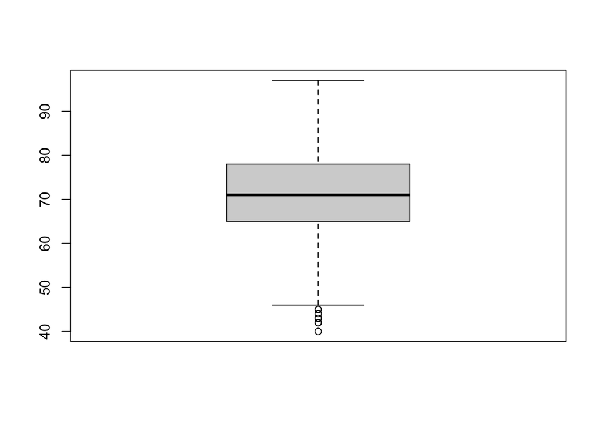

```r
boxplot(Assignmentdata$AvgHumidity)
```

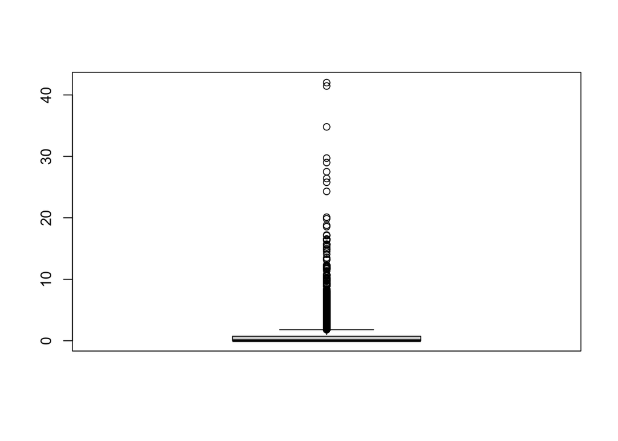

```r
boxplot(Assignmentdata$Rain)
```

This report investigates rainfall against humidity and humidity against average temperature via averaging the maximum and mininmum temperatures (approximate average). Average humidity was thus analysed individually due to its importance in research questions. It has a minimum of 40g/kg and a maximum of 97g/kg, resulting in a range of 57g/kg. With Q1=65 and Q3= 78, the IQR is 13g/kg. For average rain was a minimum of 0mm and a maximum of 42mm (one of many outliers), resulting in a range of 42mm. There is a 0.9468mm mean, Q1=0 and Q3=0.72 resulting in IQR of 0.72mm.

```r
range(Assignmentdata$Humidity)
```

```
## [1]  Inf -Inf
```

```r
IQR(Assignmentdata$Humidity)
```

```
## [1] NA
```

```r
range(Assignmentdata$Rain)
```

```
## [1]  0 42
```

```r
IQR(Assignmentdata$Rain)
```

```
## [1] 0.72
```

## 2.2 Research Question 1: At what temperatures is it most ideal to plant crops for farmers in Istanbul?(How does temperature affect humidity).

Temperature is known to have a meaningful effect on humidity as research shows that as temperature increases the relative humidity decreases. An increase in temperature increases the amount of water air can retain so if there is a constant amount of water vapour an increased temperature will increase the threshold for air to be saturated and thus decrease the relative humidity. This is why it is important to find what temperatures these humidities as high humidity promotes more photosynthesis and crop growth.

```r
cor(Assignmentdata$AvgTemp, Assignmentdata$AvgHumidity)
```

```
## [1] -0.4287064
```

```r
plot(Assignmentdata$AvgTemp, Assignmentdata$AvgHumidity)
l=lm(Assignmentdata$AvgHumidity ~ Assignmentdata$AvgTemp)
l
```

```
##
## Call:
## lm(formula = Assignmentdata$AvgHumidity ~ Assignmentdata$AvgTemp)
##
## Coefficients:
##            (Intercept)  Assignmentdata$AvgTemp
##                80.4826                 -0.5692
```

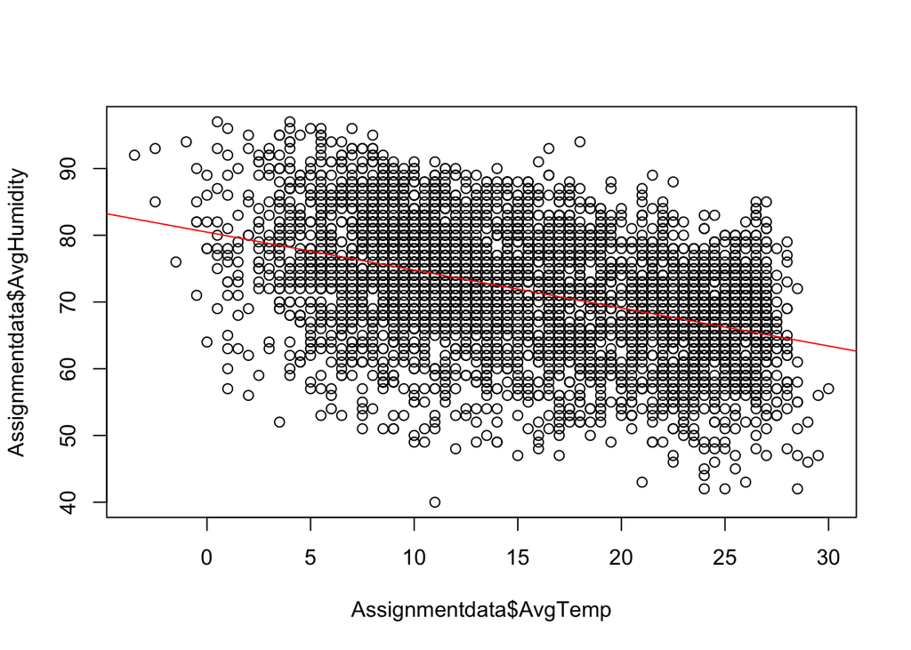

```r
abline(l, col = "red")
```

As can be seen by this scatter plot the humidity decreases with an increase in temperature. Although the correlation coefficient is low at -0.429 the two variables can still be plotted together in a linear fashion.

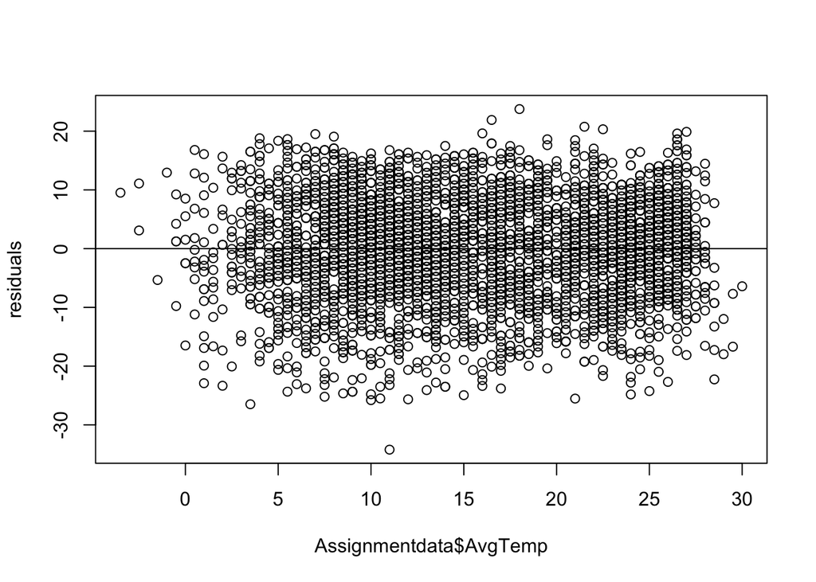

```r
plot(Assignmentdata$AvgTemp, l$residuals, ylab='residuals')
abline(h=0)
```

The scatter plot above furthers this linear correlation as the plot of the residuals shows that they are randomly scattered along the graph and don’t have any pattern. Thus, proving that although the correlation between the two variables is small they do have a direct linear correlation with each other. Thus, at lower average temperatures a higher average humidity can be seen in the data. The regression line plotted for the two variables is:

```r
print("AvgHumidity = -0.5692(AvgTemp) + 80.4826")
```

```
## [1] "AvgHumidity = -0.5692(AvgTemp) + 80.4826"
```

This regression line gives an alright estimate of what the humidity is when given the temperature but of course its main limitation is the low correlation coefficient.

To further find correlations between humidity and temperature, we have created histograms and box plots to show the interrelationships of average humidity and average temperature daily between 2009-2019, whilst also finding a summary of the data points (as seen in the code below).

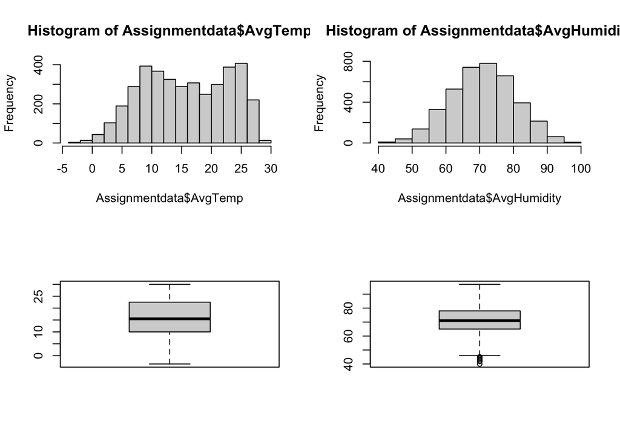

```r
par(mfrow=c(2,2))
hist(Assignmentdata$AvgTemp)
hist(Assignmentdata$AvgHumidity)
boxplot(Assignmentdata$AvgTemp)
boxplot(Assignmentdata$AvgHumidity)
```

```r
summary(Assignmentdata$AvgHumidity)
```

```
##    Min. 1st Qu.  Median    Mean 3rd Qu.    Max.
##   40.00   65.00   71.00   71.41   78.00   97.00
```

```r
sd(Assignmentdata$AvgHumidity)
```

```
## [1] 9.4835
```

```r
summary(Assignmentdata$AvgTemp)
```

```
##    Min. 1st Qu.  Median    Mean 3rd Qu.    Max.
##   -3.50   10.00   15.50   15.93   22.50   30.00
```

```r
sd(Assignmentdata$AvgTemp)
```

```
## [1] 7.142182
```

To conclude, our findings mean that low temperatures allows for humidity to be higher, allowing farmers in Istanbul to get stronger crop yields when the temperature is low, as warm air needs more humidity to reach its saturation point[1].

## 2.3 What are the trends seen between the average humidity and rainfall in Istanbul and how does this affect farming conditions?

Humidity is the level of water vapour in the air and as water vapour absorbs heat, humidity is a significant factor in the perceived temperature of an area. The higher the humidity percentage the more water vapour in the air and the more chance of rain.

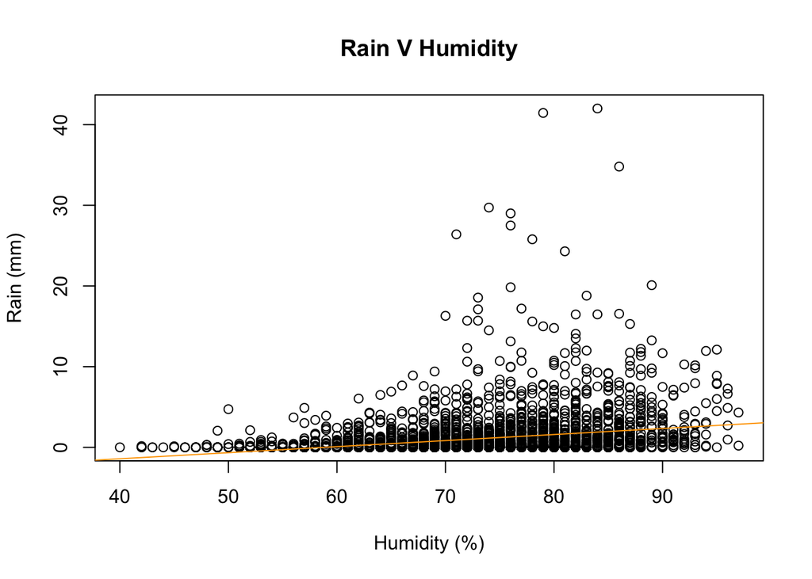

```r
plot(Assignmentdata$AvgHumidity, Assignmentdata$Rain, ylab = "Rain (mm)", xlab = "Humidity (%)", main = "Rain V Humidity")

abline(lm(Assignmentdata$Rain~Assignmentdata$AvgHumidity), col = "orange")
```

```r
lm(Assignmentdata$Rain~Assignmentdata$AvgHumidity)
```

```
##
## Call:
## lm(formula = Assignmentdata$Rain ~ Assignmentdata$AvgHumidity)
##
## Coefficients:
##                (Intercept)  Assignmentdata$AvgHumidity
##                   -4.42417                     0.07521
```

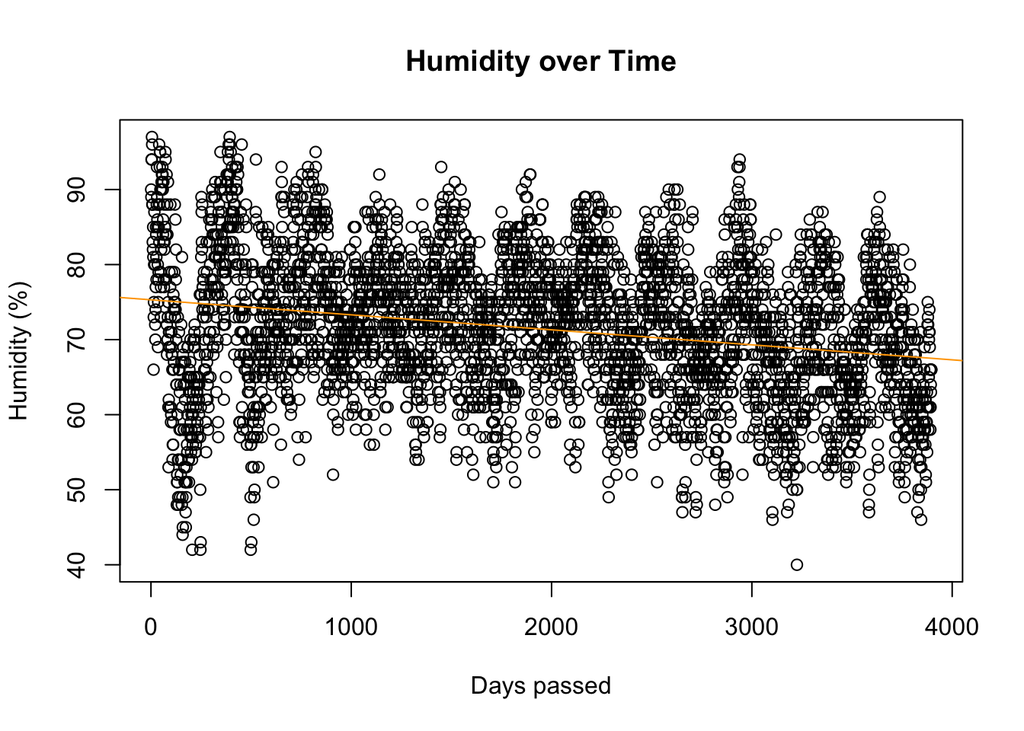

```r
#Looking at Humidity
Assignmentdata$Days_Passed = rev(1:nrow(Assignmentdata))

plot(Assignmentdata$Days_Passed, Assignmentdata$AvgHumidity, xlab = "Days passed", ylab = "Humidity (%)", main = "Humidity over Time")

abline(lm(Assignmentdata$AvgHumidity ~ Assignmentdata$Days_Passed), col = "orange")
```

```r
lm(Assignmentdata$AvgHumidity ~ Assignmentdata$Days_Passed)
```

```
##
## Call:
## lm(formula = Assignmentdata$AvgHumidity ~ Assignmentdata$Days_Passed)
##
## Coefficients:
##                (Intercept)  Assignmentdata$Days_Passed
##                  75.315566                   -0.002002
```

As seen from the linear model in the above graph, the average relative humidity in Istanbul has been roughly declining at a rate of -0.002002% daily. This is due to a steadily rising average temperature which is rising faster than the evaporation rate of water. This decrease in humidity has slightly lowered the frequency of rain in the area, showing a trend of decreasing rainfall. This can be seen in the study ‘Decreases in relative humidity across Australia’ which details similar trends of decreasing humidity and rainfall in Australia. The study uses data in Australia from 1988-2020, finding a decreasing relative humidity of around -0.8% per year, possibly leading to an increase in water scarcity.

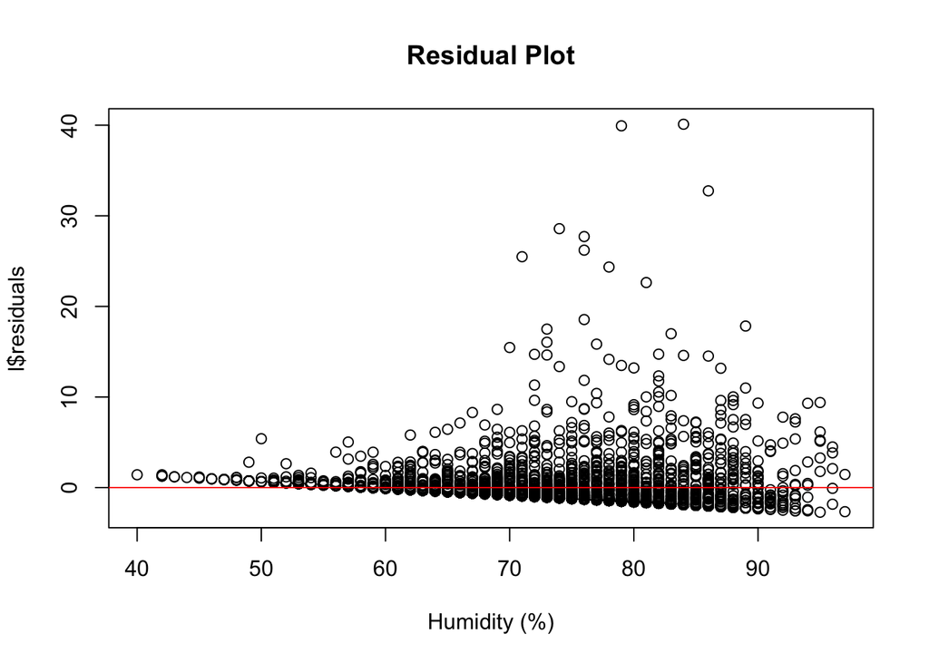

```r
#Residual plot
l = lm(Assignmentdata$Rain~Assignmentdata$AvgHumidity)
plot(Assignmentdata$AvgHumidity, l$residuals, xlab = "Humidity (%)", main = "Residual Plot")
abline(h=0, col = "red")
```

Despite displaying a correlation between the average humidity and rainfall in Istanbul, this correlation is weak with a coefficient of only 0.2787917. This weak correlation is due to the numerous external factors influencing weather conditions including wind velocity, temperature, and pressure. Along with relative humidity these can factor into the amount of rainfall occurring in an area. This weak correlation is also evident in the residual plot as there is a clear trend from the mean, so it is not homoscedastic. This may mean that the linear model may not be suitable for this data.

```r
cor(Assignmentdata$Rain,Assignmentdata$AvgHumidity, use = "complete")
```

```
## [1] 0.2787917
```

# 3 References

Earthobservatory.nasa.gov. 2022. Turkey Experiences Intense Drought. [online] Available at: <[https://earthobservatory.nasa.gov/images/147811/turkey-experiences-intense-drought>](https://earthobservatory.nasa.gov/images/147811/turkey-experiences-intense-drought%3E); [Accessed 21 September 2022]. Tcktcktck.org. 2022. Istanbul, TR Weather In August, 2019 (Weather History Aug, 2019). [online] Available at: <[https://tcktcktck.org/istanbul/august-2019>](https://tcktcktck.org/istanbul/august-2019%3E); [Accessed 21 September 2022]. Scied.ucar.edu. 2022. Climate Variability | Center for Science Education. [online] Available at: <[https://scied.ucar.edu/learning-zone/how-climate-works/climate-variability>](https://scied.ucar.edu/learning-zone/how-climate-works/climate-variability%3E); [Accessed 21 September 2022].

Timeanddate.com. 2022. Weather for Istanbul, Turkey. [online] Available at: <[https://www.timeanddate.com/weather/turkey/istanbul>](https://www.timeanddate.com/weather/turkey/istanbul%3E); [Accessed 21 September 2022]. WorldWeatherOnline.com. 2022. World Weather Online. [online] Available at: <[https://www.worldweatheronline.com>](https://www.worldweatheronline.com%3E); [Accessed 21 September 2022]. Weather Istanbul Data 2009-2019. (2022). Retrieved 21 September 2022, from https://www.kaggle.com/datasets/vonline9/weather-istanbul-data-20092019 [1]Laurenzi, T. (2022). How Does Temperature Affect Relative Humidity Meter Readings?. Retrieved 22 September 2022, from https://www.delmhorst.com/blog/relative-humidity-meter-readings ShieldSquare Captcha. (2022). Retrieved 22 September 2022, from https://iopscience.iop.org/article/10.1088/1748-9326/ac0aca Why is humidity important?. (2022). Retrieved 22 September 2022, from https://www.metoffice.gov.uk/weather/learn-about/weather/types-of-weather/humidity/effects#:~:text=During%20very%20heavy%20rainfall%2C%20where,we’re%20likely%20to%20see